# VAR Models - POC

Mihaela Solcan

23 March 2017

Load the packages

```r
library(vars)
library(urca)
library(knitr)
```

### Data

I implemented a model for the global market of crude oil following the structure used by Killian and Murphy (2009). The model includes 4 endogenous variables in logs:

- changes in global crude oil production: $\Delta oil.prod$, which captures aggregate supply shocks;
- changes in an index of economic activity, measured by the global industrial production index: $\Delta global.ip$, assumed to capture aggregate demand shocks;
- changes in real Brent oil prices, deflated using the US CPI: $\Delta roil.price$, designed to capture oil-market specific demand shocks;
- changes in global inventories of crude oil: $\Delta oil.inventory$, intended to capture speculative demand for oil.

As exogenous variables I added seasonal dummies and an indicator for the recent declines in prices (dummy) that takes the value 1 during the 2008-09 recession and during the recent decline in oil prices between 2014 and 2016.

```r
setwd("C:/Users/mfp43003/Desktop/EAA/data/")

dt<-as.zoo(ts(xlsx::read.xlsx("EAA_Test_VAR.xlsx", sheetName = "VAR data", colIndex = 8:11,
                           startRow = 2,endRow = 242, header=T), start=c(1997,1),freq=12))
dummy<-as.zoo(ts(xlsx::read.xlsx("EAA_Test_VAR.xlsx", sheetName = "VAR data", colIndex = 12,
                              startRow = 2,endRow = 242, header=T), start=c(1997,1),freq=12))
```

#### Plots of the data

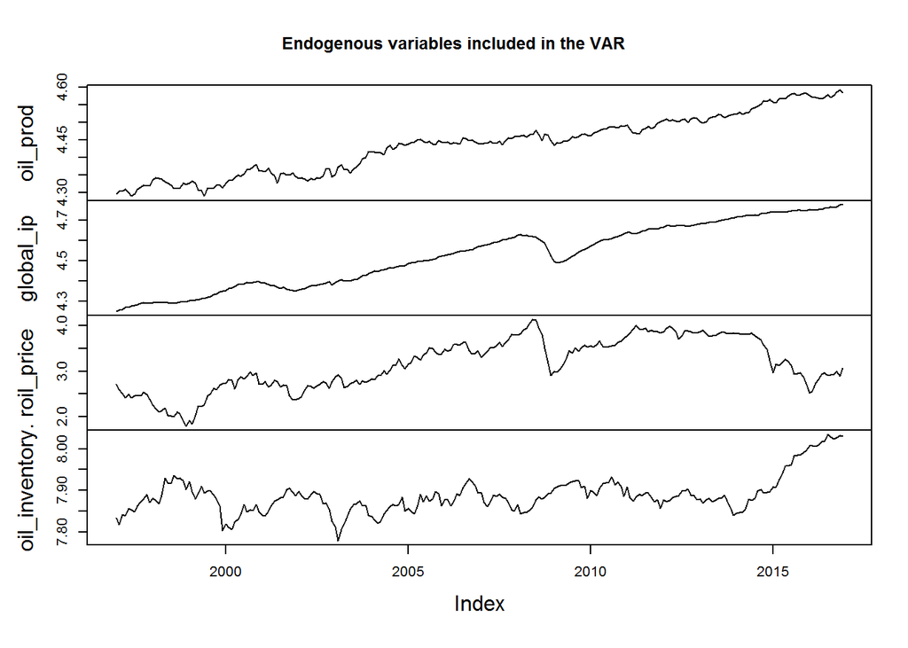

```r
plot(dt, main="Endogenous variables included in the VAR")
```

Indicator of recent declines in oil prices has been included as an exogenous variable, together with seasonal dummies:

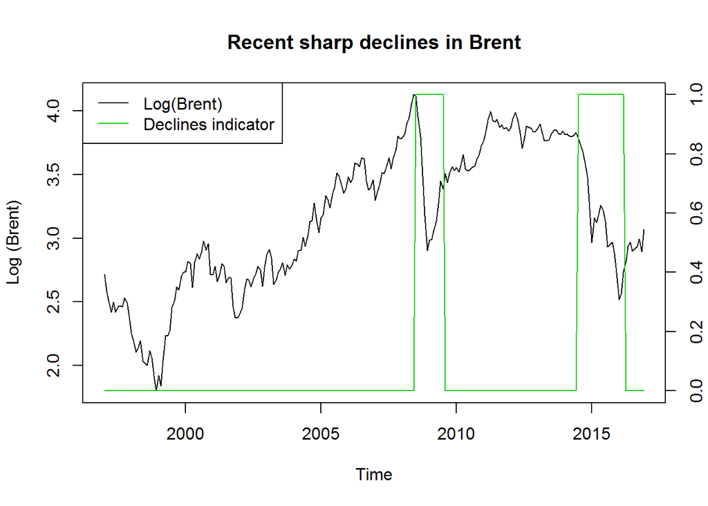

#### Stationarity

The results of the unit root tests show that all the variables included in the analysis are integrated of order 1. In other words, these are first-difference stationary. Thus, in the VAR model I used the first difference of the data.

```r
uroots<-data.frame(dt[1:6,], row.names=c("Test value - levels","Critical Value at 5%","Test result - levels",
                                         "Test value - difference", "Critical value at 5%,", "Test results - difference"))

for(i in 1:ncol(dt)){
  uroots[1,i]<-round(ur.df(dt[,i], lags=12,type=c("drift"), selectlags = "BIC")@teststat[1,2],2)
  uroots[2,i]<-ur.df(dt[,i], lags=12,type=c("drift"), selectlags = "BIC")@cval[2,2]
  uroots[3,i]<-ifelse(uroots[1,i]>uroots[2,i],"Stationary","Unit Root")
  uroots[4,i]<-round(ur.df(diff(dt[,i]), lags=12, type="none",selectlags = "BIC")@teststat[1,1],2)
  uroots[5,i]<-ur.df(diff(dt[,i]), lags=12, type="none", selectlags = "BIC")@cval[1,2]
  uroots[6,i]<-ifelse(uroots[4,i]> uroots[5,i],"Stationary","Unit Root")
}
```

Unit root test results

|  | Test value - levels | Critical Value at 5% | Test result - levels | Test value - difference | Critical value at 5%, | Test results - difference |
| --- | --- | --- | --- | --- | --- | --- |
| oil_prod | 3.52 | 4.63 | Unit Root | -12.71 | -1.95 | Stationary |
| global_ip | 2.89 | 4.63 | Unit Root | -5.32 | -1.95 | Stationary |
| roil_price | 2.26 | 4.63 | Unit Root | -9.33 | -1.95 | Stationary |
| oil_inventory. | 2.93 | 4.63 | Unit Root | -3.01 | -1.95 | Stationary |

### Data for modeling

```r
d.dt<-diff(dt,lag=1)
d.dummy<-cbind(d=dummy[2:nrow(dummy),])
```

The optimum number of lags of the endogenous variables is determined based on information criteria. A maximum number of 12 lags has been specified.

```r
VARselect(dt, lag.max = 12, type="both", season=12)
```

```
## $selection
## AIC(n)  HQ(n)  SC(n) FPE(n)
##      3      3      2      3
##
## $criteria
##                    1             2             3             4
## AIC(n) -3.417741e+01 -3.455437e+01 -3.465897e+01 -3.462959e+01
## HQ(n)  -3.376474e+01 -3.404461e+01 -3.405212e+01 -3.392563e+01
## SC(n)  -3.315462e+01 -3.329092e+01 -3.315488e+01 -3.288483e+01
## FPE(n)  1.436885e-15  9.865943e-16  8.898906e-16  9.182637e-16
##                    5             6             7             8
## AIC(n) -3.462518e+01 -3.456994e+01 -3.457075e+01 -3.450316e+01
## HQ(n)  -3.382413e+01 -3.367179e+01 -3.357550e+01 -3.341082e+01
## SC(n)  -3.263977e+01 -3.234388e+01 -3.210402e+01 -3.179579e+01
## FPE(n)  9.247626e-16  9.806021e-16  9.839741e-16  1.058241e-15
##                    9            10            11            12
## AIC(n) -3.446420e+01 -3.440014e+01 -3.434563e+01 -3.441961e+01
## HQ(n)  -3.327476e+01 -3.311360e+01 -3.296199e+01 -3.293888e+01
## SC(n)  -3.151616e+01 -3.121145e+01 -3.091629e+01 -3.074961e+01
## FPE(n)  1.107169e-15  1.189174e-15  1.266742e-15  1.188322e-15
```

```r
VARselect(d.dt, lag.max = 12, type="both",season=12)
```

```
## $selection
## AIC(n)  HQ(n)  SC(n) FPE(n)
##      2      2      1      2
##
## $criteria
##                    1             2             3             4
## AIC(n) -3.448641e+01 -3.459804e+01 -3.454632e+01 -3.451607e+01
## HQ(n)  -3.407242e+01 -3.408663e+01 -3.393750e+01 -3.380984e+01
## SC(n)  -3.346044e+01 -3.333065e+01 -3.303753e+01 -3.276588e+01
## FPE(n)  1.054943e-15  9.444635e-16  9.960502e-16  1.028726e-15
##                    5             6             7             8
## AIC(n) -3.444578e+01 -3.443251e+01 -3.435934e+01 -3.434731e+01
## HQ(n)  -3.364214e+01 -3.353145e+01 -3.336087e+01 -3.325144e+01
## SC(n)  -3.245418e+01 -3.219950e+01 -3.188492e+01 -3.163149e+01
## FPE(n)  1.106599e-15  1.125251e-15  1.215880e-15  1.237071e-15
##                    9            10            11            12
## AIC(n) -3.428240e+01 -3.423210e+01 -3.429423e+01 -3.428199e+01
## HQ(n)  -3.308912e+01 -3.294140e+01 -3.290612e+01 -3.279647e+01
## SC(n)  -3.132517e+01 -3.103347e+01 -3.085419e+01 -3.060055e+01
## FPE(n)  1.328397e-15  1.407441e-15  1.334347e-15  1.364650e-15
```

Three out of 4 information criteria selected 2 lags for the differenced data. Thus, the VAR model has been estimated with 2 lags.

```r
var1 <- VAR(d.dt, p = 2, type = "const", season=12, lag.max=12,ic="AIC", exogen=d.dummy)
```

#### Granger (lags) and instantaneous causality tests:

```r
causality(var1, cause = "oil_prod", vcov.=vcovHC(var1))
```

```
## $Granger
##
##  Granger causality H0: oil_prod do not Granger-cause global_ip
##  roil_price oil_inventory.
##
## data:  VAR object var1
## F-Test = 3.5637, df1 = 6, df2 = 864, p-value = 0.00171
##
##
## $Instant
##
##  H0: No instantaneous causality between: oil_prod and global_ip
##  roil_price oil_inventory.
##
## data:  VAR object var1
## Chi-squared = 31.205, df = 3, p-value = 7.698e-07
```

```r
MSBVAR::granger.test(dt,p=2)
```

```
##                              F-statistic      p-value
## global_ip -> oil_prod          7.1358404 0.0009820858
## roil_price -> oil_prod         1.8165922 0.1648738602
## oil_inventory. -> oil_prod     1.4060955 0.2471702993
## oil_prod -> global_ip          0.4640684 0.6293003791
## roil_price -> global_ip        9.2918527 0.0001310547
## oil_inventory. -> global_ip    0.1912563 0.8260504264
## oil_prod -> roil_price         0.2631474 0.7688567215
## global_ip -> roil_price        3.0380113 0.0498331378
## oil_inventory. -> roil_price   4.1533534 0.0168900352
## oil_prod -> oil_inventory.     2.2053715 0.1125050468
## global_ip -> oil_inventory.    2.3688243 0.0958411727
## roil_price -> oil_inventory.   0.3621792 0.6965488362
```

#### Diagnostic Tests for model var1:

```r
ser1 <- serial.test(var1, lags.pt = 6, type = "PT.asymptotic")
ser1$serial
```

```
##
##  Portmanteau Test (asymptotic)
##
## data:  Residuals of VAR object var1
## Chi-squared = 79.005, df = 64, p-value = 0.09805
```

```r
norm1 <-normality.test(var1)
norm1$jb.mul
```

```
## $JB
##
##  JB-Test (multivariate)
##
## data:  Residuals of VAR object var1
## Chi-squared = 113.89, df = 8, p-value < 2.2e-16
##
##
## $Skewness
##
##  Skewness only (multivariate)
##
## data:  Residuals of VAR object var1
## Chi-squared = 22.362, df = 4, p-value = 0.0001698
##
##
## $Kurtosis
##
##  Kurtosis only (multivariate)
##
## data:  Residuals of VAR object var1
## Chi-squared = 91.531, df = 4, p-value < 2.2e-16
```

```r
arch1 <- arch.test(var1, lags.multi = 6)
arch1$arch.mul
```

```
##
##  ARCH (multivariate)
##
## data:  Residuals of VAR object var1
## Chi-squared = 668.88, df = 600, p-value = 0.02643
```

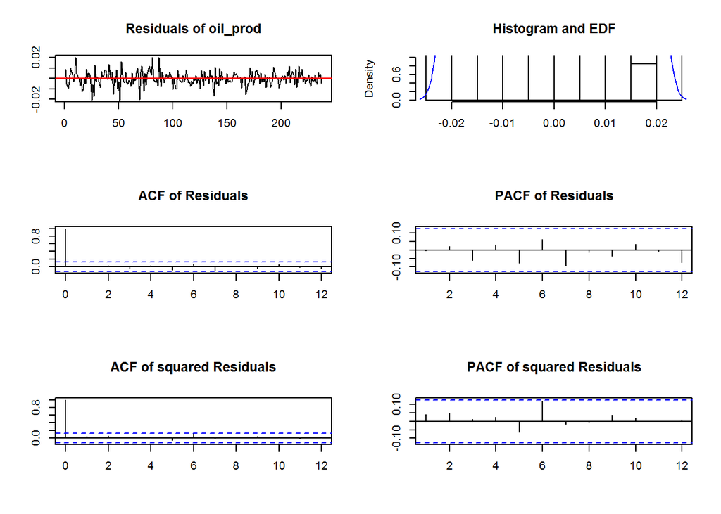

```r
plot(arch1, names = "hp")
```

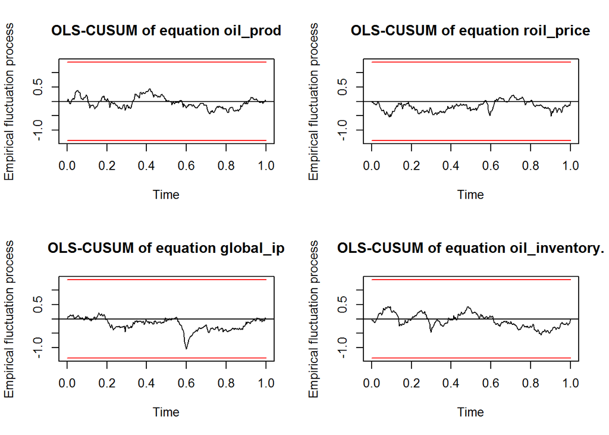

```r
plot(stability(var1), nc = 2)
```

#### Predictions

```r
dumvar<-cbind(d=rep(0,12))
var1.prd <- predict(var1, n.ahead = 12, ci = 0.95, dumvar=dumvar)
```

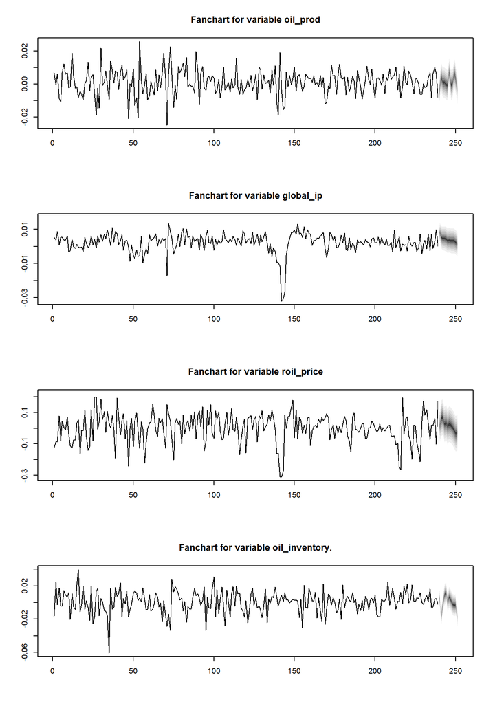

```r
fanchart(var1.prd)
```

### Scenarios: Anticipated vs. unanticipated shocks

Anticipated shocks are defined by the user through:

- forecasts of the exogenous variables; and
- conditional forecasts via user defined paths of some of the endogenous variables.

Unanticipated shocks are usually used to identify the structure of VAR models, similar to the coefficient estimates in a classical regression. These are then evaluated in terms of dynamics and statistical significance via impulse-response functions. These exogenous shocks are specified in the matrix of the error terms.

#### Exogenous shocks in the oil market

Suppose we have data on oil prices and quantities. Based on the dynamic relationship between the variables described by the reduced-form of the VAR we can forecast price and quantity in the next period. That forecast will probably be wrong as economic shocks happen.

The difference between the in-sample model forecasts and the observed price and quantity are the reduced -form errors. These reduced-form errors are caused by shifts in the demand and the supply curves. In this example, the shifts in the demand and supply curves are the underlying structural shocks.

A price errors is therefore a weighted average of demand and supply shocks with unknown weights.It is meaningless to talk about quantity shocks and supply shocks instead of demand and supply shocks, since sometimes prices change because of demand and sometimes because of supply.

The trick of VAR modelling is to find some credible way to back out the structural shocks from our observations on the reduced-form errors. In other words, to try to work out what the unknown weights are.

How can we recover the underlying demand and supply shocks from our observed in-sample errors in prices and quantities? The shocks in VAR models have names like demand, supply, monetary policy, technology, etc.

Without these exogenous structural shocks the impulse responses and variance decomposition are meaningless since all we are doing is hitting the system with a weighted average of structural shocks with unknown weights and reporting what happens. If we don’t know what the shocks are then how are we supposed to know what the responses mean?

#### Shocks in the global market for oil

Killian (2009) identified a similar model as the one presented here using a combination of sign restrictions on the impact responses and bounds on the impact of price elasticities of the oil demand and oil supply.

The matrix of errors is as follows:

$$\left[\begin{array}{c}
\epsilon_t^{\Delta oil.prod} \\
\epsilon_t^{\Delta global.ip} \\
\epsilon_t^{\Delta roil.price} \\
\epsilon_t^{\Delta oil.inventory}
\end{array}\right] =
\left[\begin{array}{cccc}
- & + & + & \times \\
- & + & - & \times \\
+ & + & + & \times \\
\times & \times & + & \times
\end{array}\right]
\left[\begin{array}{c}
u_{t}^{flow.supply}\\
u_{t}^{flow.demand}\\
u_{t}^{speculative.demand}\\
u_{t}^{other.oil.demand}
\end{array}\right]$$

#### Interpretation of the sign restrictions:

- first column: on impact, a negative flow supply shock shifts the supply curve to the left: $\downarrow$ Q $\Rightarrow$ $\uparrow$P $\Rightarrow$ $\downarrow$Econ activity; the impact on inventories is not identified, this will be estimated;
- second column: a positive flow demand shock is assumed to $\uparrow$ Q, $\uparrow$P, $\uparrow$Econ activity;
- third column: a positive speculative demand shock will have a tightening effect on oil markets, whihc will $\uparrow$ Oil inventories, $\uparrow$Q, $\uparrow$P $\Rightarrow$ $\downarrow$Econ activity.

http://www-personal.umich.edu/~lkilian/publications.html